# Impact des conférences d’Avenir Climatique

## Nombre de personnes sensibilisées

Voici l’évolution du nombre de personnes qui ont assisté aux TBC en fonction des années:

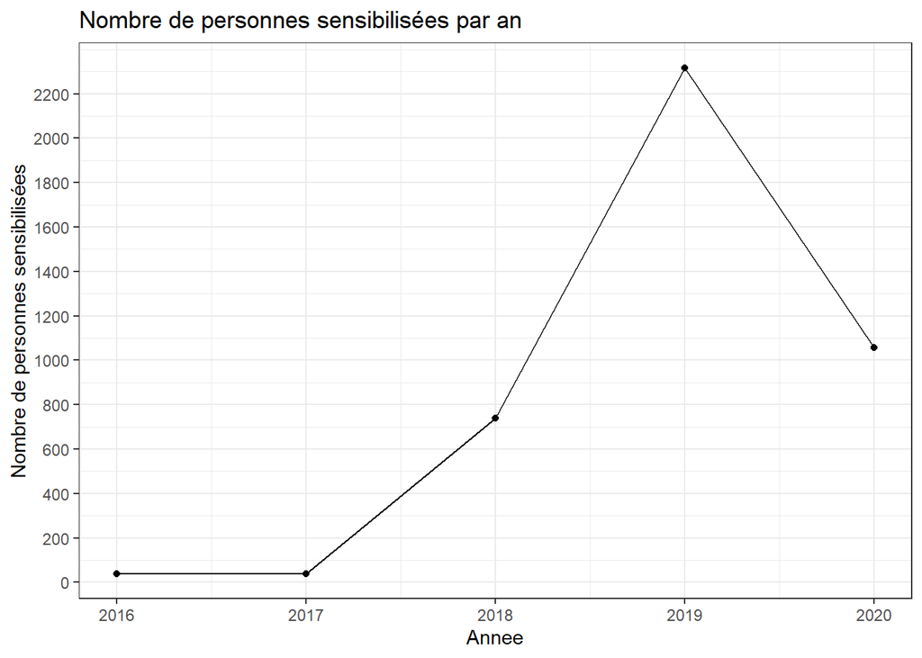

On note une forte augmentation du nombre de personnes sensibilisées. La chute observée en 2020 s’explique par:

1. L’année n’est pas terminée à l’heure où j’écris ces lignes
2. La crise du Covid-19 met à mal certaines tenues de conférences

En 2019, 2317 personnes ont assisté à des conférences d’Avenir Climatique.

Regardons le nombre de personnes sensibilisées par département:

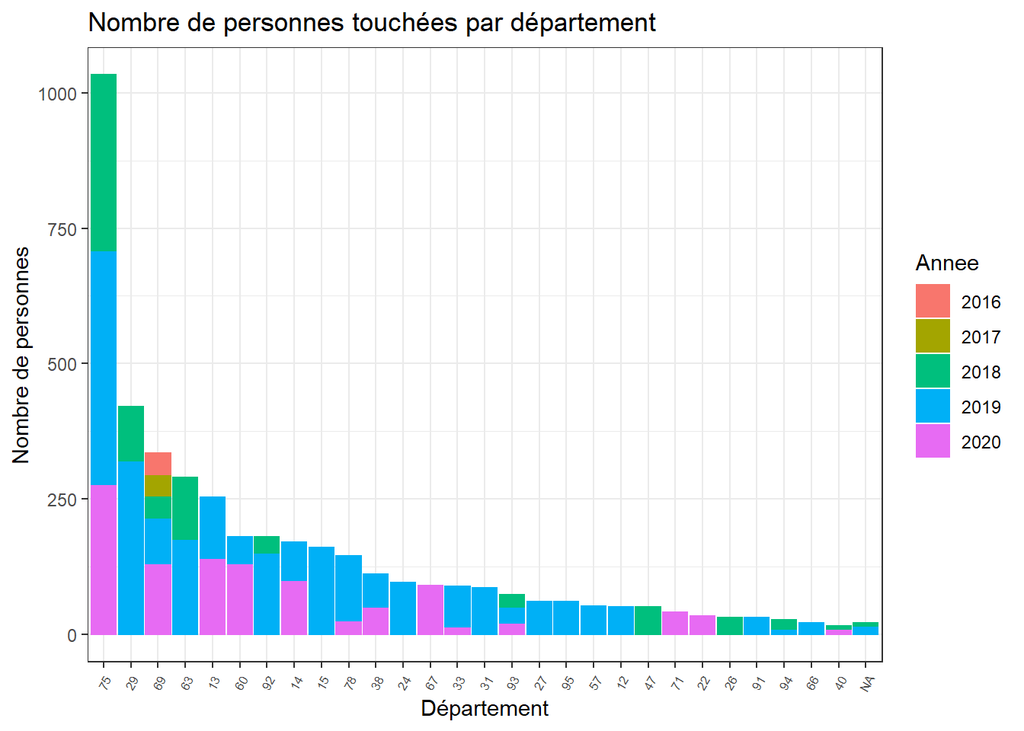

Les conférences ont principalement sensibilisé des parisiens, même si d’autres départements ont aussi eu pas mal de spectateurs (Finistère, Rhône etc.).

Voici une carte de France des spectateurs de la TBC.

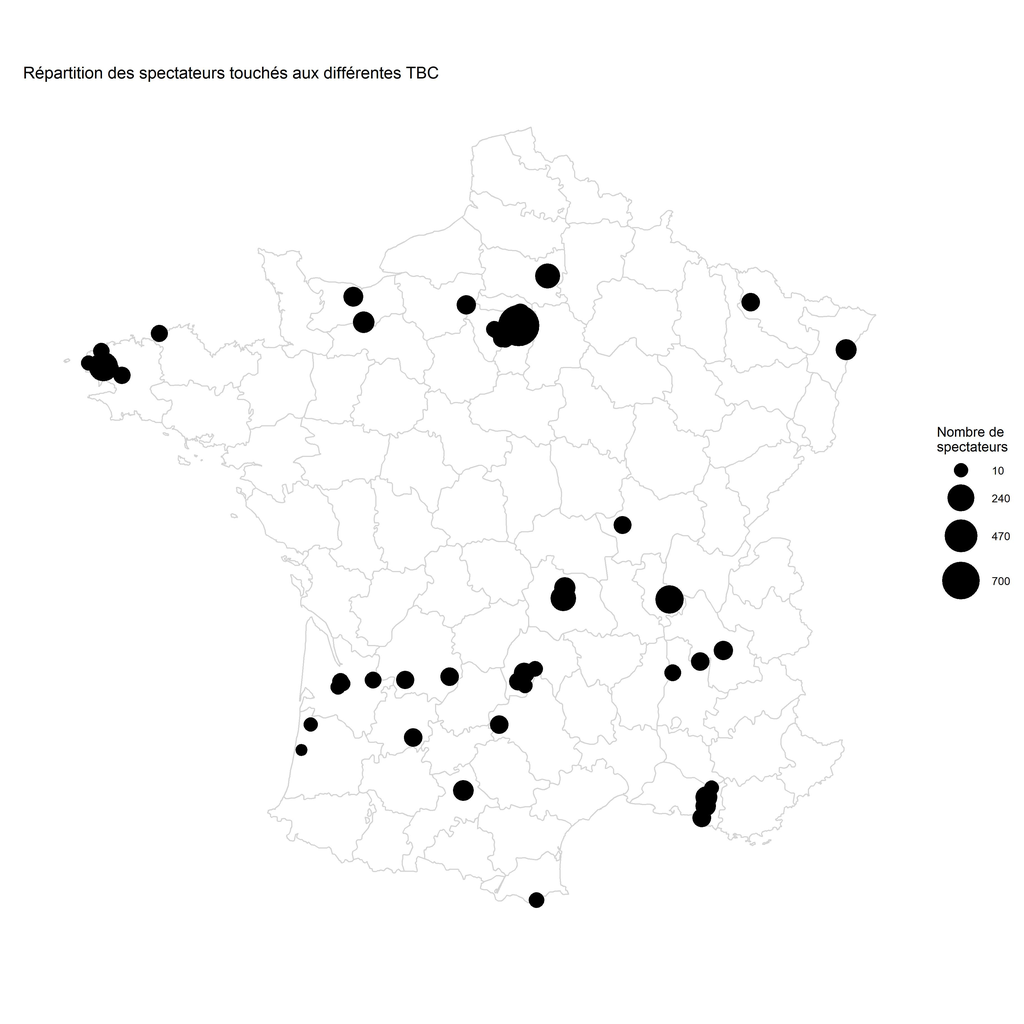

On retrouve le grand nombre de personnes sensibilisées à Paris, ainsi que le Finistrès. Certains départements de France pourraient être un peu plus sensibilisées également.

Des conférences ont eu lieu dans des villes dont nous n’avons pas les coordonnées et que nous ne pouvons donc pas représenter:

| ZARAGOZA,-ES |
| --- |
| BENEVENTO-(IT) |
| GOOGLE-MEETS |

1 conférence à été faite en Espagne, une autre en Italie et une en visio, durant l’épidémie de Covid-19.

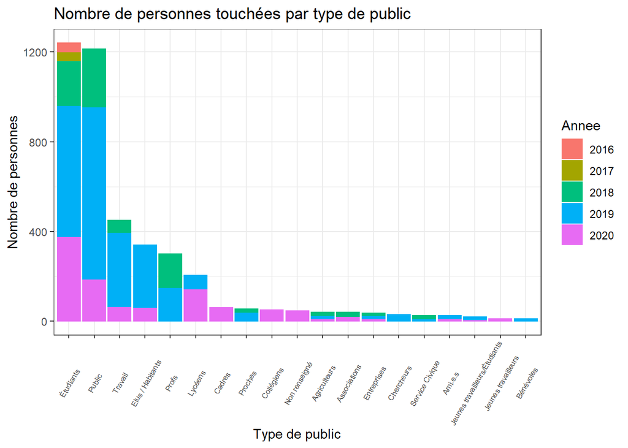

Les conférences sont principalement faites à des étudiant.e.s ou au grand public.

## Nombre de personnes par conférence

Regardons la répartition du nombre de spectateurs grâce à un diagramme dit “boîte à moustaches”:

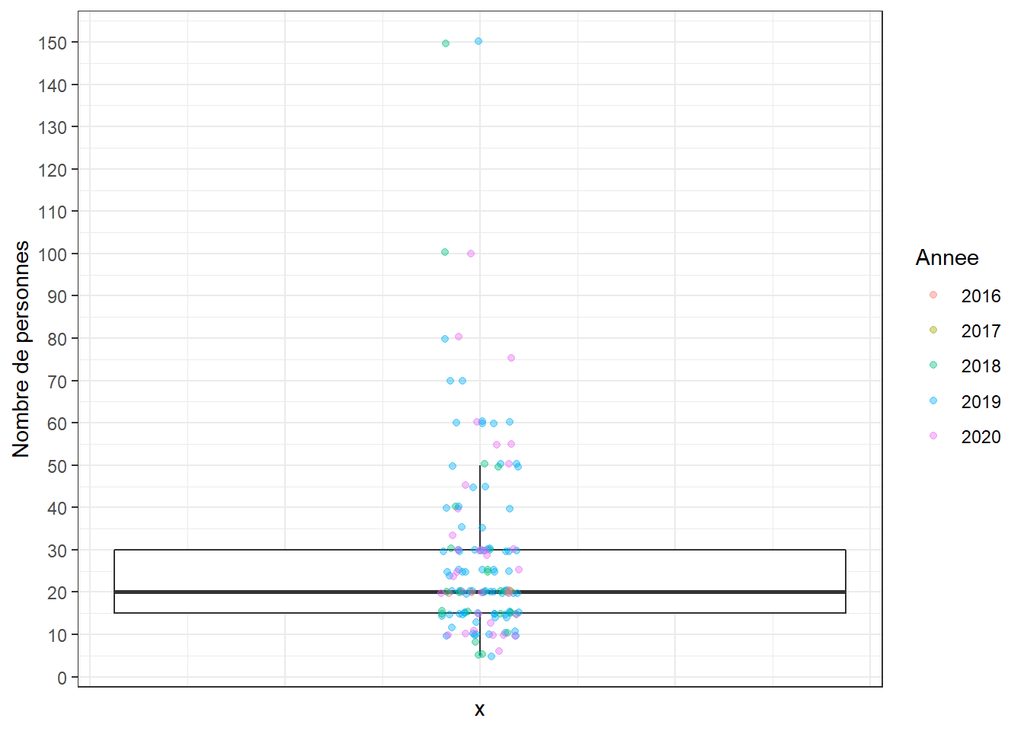

Globalement, les conférences réunissent aux alentours de 20-30 personnes. Cependant, de nombreuses coférences en réunissent plus.

On peut regarder le même graphique fait pour chaque année:

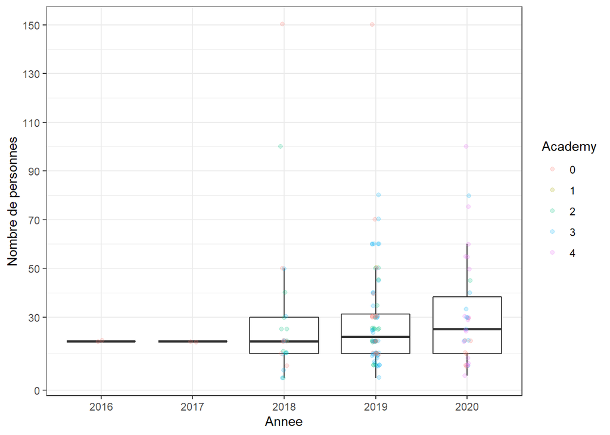

On not une légère augmentation du nombre médian de personnes par conférence au cours des années.